# IDG_2026 S-1

## "Análisis espacial para una mejor localización de agencias turísticas en el sector oriente del Gran Santiago"

#### Profesor: Matías Escudero Bell

#### Estudiante: Gabriel González Belaúnde

# INTRODUCCIÓN

El estado chileno elabora cada determinados años distintas encuestas orientadas a caracterizar de mejor forma a la sociedad en ámbitos tales como económicos, etarios, salud, educacionales, entre muchos otros. Ejemplos de estas encuestas son el CENSO, la CASEN y la EPF. Esta última (la Encuesta de Presupuestos Familiares) se centra en detallar los gastos hechos por las familias chilenas en los más variados ítems posibles. En otras palabras, por medio de sus resultados, es posible determinar a dónde y cuánto porcentaje de los ingresos de las personas u hogares son destinados a lo largo del año. Esto es bastante útil si lo que se busca es poder saber cómo es que los chilenos gastan sus ingresos y, además, es posible llevar esta información a un desglosado territorial, es decir, cómo es que estos gastos se comportan en el territorio.

Poder saber dónde es que se demandan más bienes o servicios de interés también es útil si quien hace ese análisis es parte interesada en localizar un punto más conveniente para ubicar la oferta de este bien o servicio. De esta manera, al llevar la oferta lo más cercano posible a donde está la demanda, potencialmente se podría aumentar los réditos del negocio proyectado.

El área de estudio involucra a las comunas del sector oriente del Gran Santiago (Lo Barnechea, Vitacura, Las Condes, La Reina, Ñuñoa y Providencia) donde es que se busca determinar las zonas más convenientes para la localización de una oficina vendedora de paquetes turísticos (ligada a alguna aerolínea o banco que den estos servicios).

La venta de paquetes turísticos representa una parte no menor de la economía local, considerando el aumento de turismo externo e interno en Chile (Pardo, 2025). Además, post-pandemia se ha observado un alza sostenida de los vuelos al extranjero a tal punto que se han retomado los niveles anteriores a este evento que desató una grave crisis en el rubro en su momento (JAC, 2025).

Para ello es bastante provechoso saber dónde ubicar las tiendas físicas para los titulares de este negocio. Y es que si bien la gran parte de estas ventas se realizan de forma online o directamente en el aeropuerto, persiste el uso de estos lugares por personas que prefieren la seguridad considerando los montos de dinero involucrados en la compra de pasajes al extranjero, paquetes turísticos y/o de seguros de vida. Es por ello que las tiendas físicas aún permanecen como una opción, sin olvidar que una población adulta mayor no muy familiarizada con compras online, también preferirán esta modalidad presencial (VR, 2021). La zona oriente además, se caracteriza por tener una composición social (tener buenos niveles de ingreso que permiten acceder a este tipo de servicios, presencia de adultos mayores, niveles educacionales que estimulen una mayor conexión con el extranjero, etc.) que favorece el hipotetizar acerca de una localización de este servicio en estas comunas.

# OBJETIVOS

Objetivo General:

- Hallar una localización favorable para la ubicación de sitios físicos de venta de paquetes turísticos y viajes aéreos en la zona oriente del Gran Santiago.

Objetivos Específicos:

- Analizar los resultados de la última EPF con tal de determinar qué zonas del Gran Santiago presentan la mayor demanda por el servicio estudiado.
- Generar un mapa con el cual se pueda visualizar el nivel de demanda del servicio estudiado.
- Constrastar la demanda estipulada con la oferta de sitios físicos de venta de paquetes turísticos y viajes aéreos en la zona oriente del Gran Santiago.
- Establecer las ubicaciones donde converjan alta demanda y poca oferta con el fin de definir la localización ideal de un nuevo servicio en la zona estudiada, considerando tiempos de traslado máximo mediante isocronas.

# Metodología

El presente trabajo inició con una revisión de los ítems medidos por la Encuesta de Presupuestos Familiares filtrando sus resultados para el Gran Santiago.

El fin de todo lo realizado es la constatación de lugares óptimos para la ubicación de un servicio de interés en base a un análisis de su demanda y oferta. En este sentido, la variable (servicio) que se decidió estudiar son los puntos de venta físicos (tiendas/oficinas) de paquetes turísticos y viajes aéreos. La EPF los codifica de tal manera que esos códigos son los usados para el estudio de cómo es que se comporta su demanda en función a aspectos demográficos (edad, educación, ingresos, etc.), de tal manera que luego es posible espacializar su demanda.

Con todo, la codificación utilizada en términos generales corresponden a gastos en transporte aéreo nacional e internacional, tasas de embarque y paquetes turísticos.

A lo largo del trabajo se manejan los datos de la EPF con tal de indentificar aquellas zonas del Gran Santiago con una mayor demanda del servicio analizado. Para ello se deben hacer una regresión de tipo Logit y otra de Regresión Lineal Múltiple, con variables extraídas desde la CASEN, debiéndose para tales fines recodificar las variables con las que se estima la demanda del servicio. Todo ello se visualiza mediante la espacialización de la demanda según zonas censales (usando las del CENSO 2024).

Por otra parte, también se debe considerar la oferta de estos servicios, para lo cual se deben tener 3 capas de tipo geojson: una de las comunas en estudio, otra con las zonas censales de las mismas, y otra con los puntos de venta reales. El por qué deben estar en este formaato es debido a que gracias a ello se pueden crear isocronas alrededor de los puntos de venta y considerando la red vial de la zona. Esto nos otroga el grado de cobertura de la oferta en la comuna en base a la influencia que tienen para caminatas a su alrededor por 15 minutos.

Con todo lo anterior es que se pueden identificar aquellas zonas con mayor y menor cobertura considerando a la vez el nivel de demanda existente. A partir de esto es que se pueden establecer y definir determinados puntos donde resultaría provechoso ubicar un nuevo punto de venta de paquetes turísticos y viajes aéreos considerando zonas con alta demanda estimada pero con poca o nula cobertura de la oferta. Para esto también se estima a modo de orientación un índice territorial sobre oferta/demanda en la zona.

# Desarrollo

Primero siempre en el desarrollo se encuentra lo que es la carga de librerías y de los archivos a usar:

```python
!pip install pyreadr
!pip install ipfn
!pip install contextily
!pip install osmnx
!pip install shapely
!pip install statsmodels
```

[output not shown]

[output cut: 120 more lines]

[output not shown]

```python
import os

os.environ.pop('PROJ_LIB', None)
os.environ.pop('PROJ_DATA', None)
os.environ.pop('GDAL_DATA', None)


import numpy as np
import pandas as pd
import geopandas as gpd
import pyreadr
import matplotlib.pyplot as plt
import matplotlib.patheffects as pe
import matplotlib.ticker as ticker
import seaborn as sns
import statsmodels.formula.api as smf
from sklearn.linear_model import LinearRegression
from sklearn.metrics import roc_auc_score, roc_curve
from ipfn import ipfn
import contextlib
import io
import warnings
import mapclassify
import contextily as cx
import osmnx as ox
import networkx as nx
from shapely.geometry import shape, Point
from shapely.wkt import loads
```

```python
RUTA_CENSO_ZONAL = "../DATA/tf/Cartografía_censo2024_R13_Zonal.parquet"
RUTA_CENSO_COMUNAL = "../DATA/tf/Cartografía_censo2024_R13_Comunal.parquet"
RUTA_CASEN = "../DATA/CASEN24/casen_rm.rds"
RUTA_CSV_EPF = "../DATA/EPF/ccif-ix-epf-(formato-csv).csv"
RUTA_EPF_PERSONAS = "../DATA/EPF/base-personas-ix-epf-stata.dta"
RUTA_EPF_CANTIDADES = "../DATA/EPF/base-cantidades-ix-epf-stata.dta"

SEED = 727
```

Luego, empezamos por seleccionar la variable sujeta de estudio dentro de todas de las que la EPF contiene, filtrando inicialmente que los datos que sean manejados correspondan al Gran Santiago (macrozona = 2) y que los valores no sean nulos (ceros) en cuanto a edad, ingreso y educacional.

```python
personas = pd.read_stata(RUTA_EPF_PERSONAS, convert_categoricals=False)
cantidades = pd.read_stata(
    RUTA_EPF_CANTIDADES, convert_categoricals=False,
    columns=["folio", "n_linea", "ccif", "macrozona", "gasto"],
)

valores_invalidos = [-99, -88, -77]
epf = personas[
    (personas["macrozona"] == 2)
    & (~personas["edad"].isin(valores_invalidos))
    & (~personas["edue"].isin(valores_invalidos))
    & (personas["ing_disp_hog_hd_ai"] >= 0)
].copy()

epf["ing_pc"] = epf["ing_disp_hog_hd_ai"] / epf["npersonas"]

# id_persona: forzamos n_linea a entero ANTES de convertir a texto, en ambas bases
epf["id_persona"] = epf["folio"].astype(str) + "_" + epf["n_linea"].astype("Int64").astype(str)
cantidades["id_persona"] = cantidades["folio"].astype(str) + "_" + cantidades["n_linea"].astype("Int64").astype(str)
```

```python
ccif = pd.read_csv(RUTA_CSV_EPF,
                   sep = None, engine = "python", encoding = "utf-8-sig",)

CODIGO_CCIF = "07.3.3.00.00", "09.8.0.00.00", "09.8.1.00.00", "09.8.1.01.00", "09.8.1.01.01","09.8.1.01.02",
"09.8.1.02.00", "09.8.1.02.88", "09.8.1.03.00", "09.8.1.03.88", "07.3.3.02.01",
"07.3.3.02.02", "07.3.3.02.03", "07.3.3.01.00", "07.3.3.01.01","07.3.3.01.02", "07.3.3.01.03", "07.3.3.02.00"

ccif[ccif['ccif'].isin(CODIGO_CCIF)]
```

|  | d | g | c | sc | p | ccif | glosa_ccif |
| --- | --- | --- | --- | --- | --- | --- | --- |
| 1061 | 7 | 3 | 3 | 0 | 0 | 07.3.3.00.00 | TRANSPORTE DE PASAJEROS POR VÍA AÉREA (S) |
| 1353 | 9 | 8 | 0 | 0 | 0 | 09.8.0.00.00 | PAQUETES TURÍSTICOS |
| 1354 | 9 | 8 | 1 | 0 | 0 | 09.8.1.00.00 | PAQUETES TURÍSTICOS (S) |
| 1355 | 9 | 8 | 1 | 1 | 0 | 09.8.1.01.00 | PAQUETES TURÍSTICOS (S) |
| 1356 | 9 | 8 | 1 | 1 | 1 | 09.8.1.01.01 | PAQUETES TURÍSTICOS NACIONALES |
| 1357 | 9 | 8 | 1 | 1 | 2 | 09.8.1.01.02 | PAQUETES TURÍSTICOS INTERNACIONALES |

Lo anterior sirve para ver el detalle de las variables buscadas dentro de la EPF. Como el servicio deseado a ubicar trata sobre la venta de paquetes turísticos y viajes aéreos, todos los ítems señalados con sus códigos se vinculan con lo que se busca modelar, y por tanto son todas estas las escogidas para lo que viene a continuación:

Una vez identificados los ítems necesarios, se observa la cantidad de personas que incurren en estos gastos para luego modelar.

```python
personas = pd.read_stata("../DATA/EPF/base-personas-ix-epf-stata.dta", convert_categoricals=False)
gastos = pd.read_stata(
    "../DATA/EPF/base-gastos-ix-epf-stata.dta", convert_categoricals=False,
    columns=["folio", "ccif", "macrozona", "gasto"],
)

# mismo filtro de siempre: Gran Santiago y códigos de no respuesta afuera
valores_invalidos = [-99, -88, -77]
epf = personas[
    (personas["macrozona"] == 2)
    & (~personas["edad"].isin(valores_invalidos))
    & (~personas["edue"].isin(valores_invalidos))
    & (personas["ing_disp_hog_hd_ai"] >= 0)
].copy()
epf["ing_pc"] = epf["ing_disp_hog_hd_ai"] / epf["npersonas"]

codigo_viajes = [
    "07.3.3.00.00", "09.8.0.00.00", "09.8.1.00.00", "09.8.1.01.00", "09.8.1.01.01",
    "09.8.1.01.02", "09.8.1.02.00", "09.8.1.02.88", "09.8.1.03.00", "09.8.1.03.88",
    "07.3.3.02.01","07.3.3.02.02", "07.3.3.02.03", "07.3.3.01.00", "07.3.3.01.01",
    "07.3.3.01.02", "07.3.3.01.03", "07.3.3.02.00"
]

gasto_viajes = gastos[gastos["ccif"].isin(codigo_viajes) & (gastos["macrozona"] == 2)]
gasto_por_hogar = gasto_viajes.groupby("folio")["gasto"].sum().reset_index()
gasto_por_hogar.columns = ["folio", "gasto_viajes"]

epf = epf.merge(gasto_por_hogar, on="folio", how="left")
epf["gasto_viajes"] = epf["gasto_viajes"].fillna(0)
epf["incurre_gasto"] = (epf["gasto_viajes"] > 0).astype(int)

print(f"Hogares con viajes: {len(gasto_por_hogar)}")
print(f"Incurren en el gasto: {epf['incurre_gasto'].sum()} / {len(epf)}")
```

```
Hogares con viajes: 720
Incurren en el gasto: 1993 / 17340
```

```python
# Recodificar para calzar con CASEN

epf["grupo_escolaridad"] = pd.cut(
    epf["edue"], bins=[-np.inf, 12, 14, 16, np.inf],
    labels=["Escolar", "Tecnico", "Universitaria", "Postgrado"],
)
epf["rango_edad"] = pd.cut(
    epf["edad"], bins=[-1, 29, 44, 64, np.inf],  # -1 (no 0) para que edad=0 (recién nacidos) quede incluido
    labels=["jovenes", "adultos_jovenes", "adultos", "adultos_mayores"],
)
epf["sexo_lbl"] = epf["sexo"].map({1: "Hombre", 2: "Mujer"})
```

Antes de modelar, bien vale observar el comportamiento del gasto en el ítem estudiado según factores económicos, educacionales y etarios. Esta es una forma también de ir anticipando posibles escenarios, no sólo de lo que arroje de las regresiones, sino de cómo será el comportamiento en el área de estudio de la demanda por el servicio analizado.

[output not shown]

[figure not shown]

```python
# GRUPO DE GRÁFICOS PARA CARACTERIZAR EL COMPORTAMIENTO DEL CASO DE ESTUDIO
spenders = epf[epf["gasto_viajes"] > 0]
tope_grafico = spenders["gasto_viajes"].quantile(0.99)
fig, axes = plt.subplots(4, 2, figsize=(12, 17))

# 1) Gasto según rango de edad
sns.boxplot(data=spenders, x="rango_edad", y="gasto_viajes", ax=axes[0, 0], color="#D23369")
axes[0, 0].set_ylim(0, tope_grafico)
axes[0, 0].set_title("Nivel de gasto según rango de edad")
axes[0, 0].set_xlabel("")
axes[0, 0].set_ylabel("Nivel de Gasto anual (pesos chilenos)")

# 2) Gasto según nivel de escolaridad
sns.boxplot(data=spenders, x="grupo_escolaridad", y="gasto_viajes", ax=axes[0, 1], color="#6BA4B8")
axes[0, 1].set_ylim(0, tope_grafico)
axes[0, 1].set_title("Nivel de gasto según nivel de escolaridad")
axes[0, 1].set_xlabel("")
axes[0, 1].set_ylabel("Nivel de Gasto anual (pesos chilenos)")

# 3) Proporción que incurre en gasto según rango de edad
sns.barplot(data=epf, x="rango_edad", y="incurre_gasto", ax=axes[1, 0], color="#D23369", errorbar=None)
axes[1, 0].set_title("Distribución del gasto según rango de edad")
axes[1, 0].set_xlabel("")
axes[1, 0].set_ylabel("Proporción que incurre en el gasto")

# 4) Incidencia de gasto según grupo de escolaridad
orden_escolaridad = ["Escolar", "Tecnico", "Universitaria", "Postgrado"]
sns.barplot(data=epf, x="grupo_escolaridad", y="incurre_gasto", order=orden_escolaridad, ax=axes[1, 1], color="#6BA4B8", errorbar=None)
axes[1, 1].set_title("Distribución del gasto según eduación")
axes[1, 1].set_xlabel("")
axes[1, 1].set_ylabel("Proporción que incurre en el gasto")

# 5) Incidencia de gasto según sexo
sns.barplot(data=epf, x="sexo_lbl", y="incurre_gasto", ax=axes[2, 0], color="#9b6fa8", errorbar=None)
axes[2, 0].set_title("Distribución del gasto según sexo")
axes[2, 0].set_xlabel("Sexo")
axes[2, 0].set_ylabel("Proporción que incurre en el gasto")

# 6) Distribución del gasto, solo entre quienes gastan
sns.histplot(spenders["gasto_viajes"], bins=30, color="#FFA500", ax=axes[2, 1])
axes[2, 1].set_xlim(0, tope_grafico)
axes[2, 1].set_title("Montos de gasto (sólo quienes gastan)")
axes[2, 1].set_xlabel("Nivel de Gasto anual (pesos chilenos)")
axes[2, 1].set_ylabel("N° de personas")

# 7) Ingreso vs. gasto, con curva de tendencia suavizada
sns.regplot(
    data=spenders, x="ing_pc", y="gasto_viajes", ax=axes[3, 1],
    scatter_kws={"alpha": 0.25, "s": 15, "color": "black"},
    lowess=True, line_kws={"color": "blue"},
)
axes[3, 1].set_ylim(0, tope_grafico)
axes[3, 1].set_xlim(0, spenders["ing_pc"].quantile(0.99))
axes[3, 1].set_title("Ingreso per cápita vs. gasto")
axes[3, 1].set_xlabel("Ingreso promedio")
axes[3, 1].set_ylabel("Nivel de Gasto anual (pesos chilenos)")
axes[3, 0].axis('off')

plt.tight_layout()
plt.show()
```

La anterior exploración acerca del comportamiento del gasto en viajes (paquetes turísticos y viajes aéreos) según factores económicos y demográficos, nos da cuenta de varias situaciones. Entre ellas, la primera es que se denota que a mayor nivel de ingresos, más gastos en general se realizan en viajes. Esto interpretándose de que una mejor situación económica personal y del hogar da la posibilidad a que se puedan destinar parte del presupuesto a este ítem.

En relación con la cantidad gastada en general en el ítem estudiado, estos por lo general se concentran en montos menores (aunque eso no quita que existan casos de gastos millonarios), lo que se condice con el hecho (JAC, 2025) de que en Chile, los viajes turísticos se concentran en la región (Brasil, Argentina, Colombia o Perú), con lo cual de por sí los gastos no serían tan elevados si en cambio la preferencia fuera por destinos más costos como Europa, Oceanía u algún destino exótico africano.

Por otro lado, en cuanto al nivel educacional, destaca claramente que a mayor nivel educacional en general también conlleva a un mayor gasto en viajes, sobre todo en la categoría de personas con estudios de postgrado. Estos último son los que más gastan en proporción (N°) y en cantidad ($), evidenciándose una tendencia similar con lo dicho respecto al nivel educacional y el nivel de gastos en los otros casos.

Por el contrario, la relación entre edad y los gastos hechos en viajes no representa una relación tan clara como la anterior. Se tiene en este sentido que quienes más gastan en viajes proporcionalmente son los adultos jóvenes. No obstante, no son los que más cantidad de dinero terminan gastando al respecto, sino que esos son los adultos seguidos de los jóvenes. Respecto a los primeros, se puede interpretar que a dicha edad pueden poseer una mejor situación económica (más consolidada) que los adultos jovénes y que en base a eso pueden incurrir en mayores niveles de gastos. Queda por ver en estudios futuros no obstante si esta tendencia se mantiene (relación entre estabilidad económica, grupo etario y niveles de gastos), o empieza a cambiar por ejemplo en que la categoría de adultos también aumente en proporción, lo que evidenciaría una tendencia más bien relacionada con el comportamiento generacional en que los ahora adultos jóvenes tiendan a viajar más y, de ser así, mantengan aquel comportamiento en edades mayores. Esto, nuevamente, queda a cargo de estudios posteriores y que pueden significar un potencial interés en las empresas relacionadas dado que de alguna forma esto daría cuenta del futuro del rubro y, si acaso, la situación actual de repunte de viajes (IATA, 2024) se mantiene o no.

A continuación es que se realizan las regresiones. Primero una de tipo Logit que indique la probabilidad efectiva del gasto dentro de la población, y otra de carácter Lineal Múltiple sobre el nivel de gasto en sí en base a distintas variables:

```
                           Logit Regression Results
==============================================================================
Dep. Variable:          incurre_gasto   No. Observations:                17340
Model:                          Logit   Df Residuals:                    17333
Method:                           MLE   Df Model:                            6
Date:                Wed, 26 Aug 2026   Pseudo R-squ.:                  0.1218
Time:                        16:27:00   Log-Likelihood:                -5431.8
converged:                       True   LL-Null:                       -6185.4
Covariance Type:            nonrobust   LLR p-value:                     0.000
=========================================================================================================
                                            coef    std err          z      P>|z|      [0.025      0.975]
---------------------------------------------------------------------------------------------------------
Intercept                               -14.3196      0.461    -31.031      0.000     -15.224     -13.415
C(sexo_lbl)[T.Mujer]                      0.0824      0.051      1.630      0.103      -0.017       0.182
C(grupo_escolaridad)[T.Tecnico]           0.3995      0.087      4.570      0.000       0.228       0.571
C(grupo_escolaridad)[T.Universitaria]     0.5732      0.076      7.495      0.000       0.423       0.723
C(grupo_escolaridad)[T.Postgrado]         0.7585      0.068     11.076      0.000       0.624       0.893
edad                                     -0.0118      0.001     -9.237      0.000      -0.014      -0.009
log_ing_pc                                0.9344      0.035     26.811      0.000       0.866       1.003
=========================================================================================================
AUC: 0.751173693187118
```

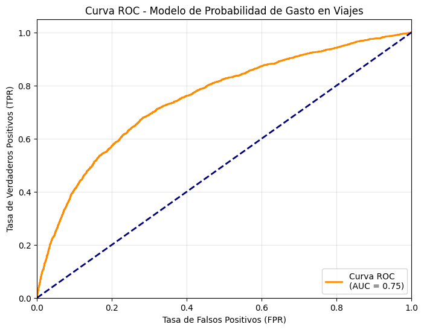

```python
epf["grupo_escolaridad"] = pd.cut(
    epf["edue"], bins=[-np.inf, 12, 14, 16, np.inf],
    labels=["Escolar", "Tecnico", "Universitaria", "Postgrado"],
)
epf["sexo_lbl"] = epf["sexo"].map({1: "Hombre", 2: "Mujer"})
epf["log_ing_pc"] = np.log(epf["ing_pc"] + 1)  # el ingreso viene muy sesgado, se ajusta mejor en log

modelo_data = epf.dropna(subset=["edad", "grupo_escolaridad", "sexo_lbl", "log_ing_pc"]).copy()

modelo_logit = smf.logit(
    "incurre_gasto ~ C(sexo_lbl) + edad + C(grupo_escolaridad) + log_ing_pc",
    data=modelo_data,
).fit(disp=0)

modelo_data["prob_predicha"] = modelo_logit.predict(modelo_data)
print(modelo_logit.summary())
print("AUC:", roc_auc_score(modelo_data["incurre_gasto"], modelo_data["prob_predicha"]))

# Gráfico de la curva ROC:
fpr, tpr, thresholds = roc_curve(modelo_data['incurre_gasto'], modelo_data['prob_predicha'])
auc_value = roc_auc_score(modelo_data['incurre_gasto'], modelo_data['prob_predicha'])

plt.figure(figsize=(8, 6))
plt.plot(fpr, tpr, color='darkorange', lw=2, label=f'Curva ROC \n(AUC = {auc_value:.2f})')
plt.plot([0, 1], [0, 1], color='navy', lw=2, linestyle='--')
plt.xlim([0.0, 1.0])
plt.ylim([0.0, 1.05])
plt.xlabel('Tasa de Falsos Positivos (FPR)')
plt.ylabel('Tasa de Verdaderos Positivos (TPR)')
plt.title('Curva ROC - Modelo de Probabilidad de Gasto en Viajes')
plt.legend(loc="lower right")
plt.grid(alpha=0.3)
plt.show()
```

Lo anterior no sólo nos indica que la regresión en rasgos generales se relaciona correctamente con los casos observados (véase el ajuste que tiene), sino que además nos señala que efectivamente que la gente a partir de las variables estipuladas para la regresión cumple con un mayor o menor gasto según dichas variables (etarias, ingresos, educación).

En cuanto a la Regresión Lineal Múltiple, a continuación se ejecuta esta considerando una limpieza de outliers referentes a, por ejemplo, ingresos y gastos excesivamente fuera de la norma:

```python
tabla_gasto = epf[epf['gasto_viajes'] > 0].copy()
tabla_gasto['log_gasto_viajes'] = np.log(tabla_gasto['gasto_viajes'] + 1)

# Limpieza de outliers
q_ing = tabla_gasto['ing_pc'].quantile([0.01, 0.99])
q_gasto = tabla_gasto['gasto_viajes'].quantile([0.01, 0.99])
tabla_gasto = tabla_gasto[
    tabla_gasto['ing_pc'].between(q_ing.iloc[0], q_ing.iloc[1])
    & tabla_gasto['gasto_viajes'].between(q_gasto.iloc[0], q_gasto.iloc[1])
]

# Nueva fórmula con variables adicionales: npersonas y edad al cuadrado
formula = "log_gasto_viajes ~ C(sexo_lbl) + edad + C(grupo_escolaridad) + log_ing_pc + npersonas + C(estrato_muestreo)"
# estrato_muestreo Como proxy de segmentación socioeconómica geográfica


modelo_lineal = smf.ols(formula, data=tabla_gasto).fit()

print(f"n = {len(tabla_gasto)}")
print(modelo_lineal.summary())
```

```
n = 1922
                            OLS Regression Results
==============================================================================
Dep. Variable:       log_gasto_viajes   R-squared:                       0.142
Model:                            OLS   Adj. R-squared:                  0.124
Method:                 Least Squares   F-statistic:                     8.170
Date:                Wed, 26 Aug 2026   Prob (F-statistic):           1.46e-40
Time:                        16:27:23   Log-Likelihood:                -3075.8
No. Observations:                1922   AIC:                             6230.
Df Residuals:                    1883   BIC:                             6446.
Df Model:                          38
Covariance Type:            nonrobust
=========================================================================================================
                                            coef    std err          t      P>|t|      [0.025      0.975]
---------------------------------------------------------------------------------------------------------
Intercept                                 5.2352      0.688      7.611      0.000       3.886       6.584
C(sexo_lbl)[T.Mujer]                      0.0007      0.056      0.013      0.989      -0.109       0.110
C(grupo_escolaridad)[T.Tecnico]          -0.0196      0.099     -0.197      0.843      -0.214       0.175
C(grupo_escolaridad)[T.Universitaria]    -0.1202      0.086     -1.405      0.160      -0.288       0.048
C(grupo_escolaridad)[T.Postgrado]        -0.0636      0.075     -0.843      0.399      -0.212       0.084
C(estrato_muestreo)[T.16]                 0.0680      0.343      0.198      0.843      -0.605       0.741
C(estrato_muestreo)[T.17]                -0.5993      0.333     -1.798      0.072      -1.253       0.054
C(estrato_muestreo)[T.18]                -0.1863      0.375     -0.497      0.620      -0.922       0.550
C(estrato_muestreo)[T.19]                 0.1864      0.356      0.523      0.601      -0.512       0.885
C(estrato_muestreo)[T.20]                -0.1794      0.346     -0.519      0.604      -0.857       0.498
C(estrato_muestreo)[T.40]                 0.2989      0.335      0.891      0.373      -0.359       0.957
C(estrato_muestreo)[T.41]                 0.2613      0.343      0.761      0.447      -0.412       0.934
C(estrato_muestreo)[T.42]                 0.2575      0.360      0.715      0.475      -0.449       0.964
C(estrato_muestreo)[T.43]                 0.1434      0.295      0.486      0.627      -0.435       0.722
C(estrato_muestreo)[T.44]                 0.2984      0.313      0.954      0.340      -0.315       0.912
C(estrato_muestreo)[T.45]                 0.1958      0.332      0.590      0.555      -0.455       0.847
C(estrato_muestreo)[T.46]                 0.8449      0.338      2.501      0.012       0.182       1.508
C(estrato_muestreo)[T.47]                 0.0292      0.331      0.088      0.930      -0.619       0.678
C(estrato_muestreo)[T.48]                 0.8146      0.320      2.548      0.011       0.188       1.442
C(estrato_muestreo)[T.49]                -0.3950      0.327     -1.206      0.228      -1.037       0.247
C(estrato_muestreo)[T.50]                -0.2772      0.349     -0.795      0.427      -0.961       0.407
C(estrato_muestreo)[T.51]                 0.2075      0.322      0.644      0.520      -0.425       0.840
C(estrato_muestreo)[T.66]                 0.7028      0.307      2.290      0.022       0.101       1.305
C(estrato_muestreo)[T.67]                 0.1787      0.300      0.595      0.552      -0.410       0.767
C(estrato_muestreo)[T.68]                -0.0885      0.326     -0.272      0.786      -0.727       0.550
```

[output cut: 10 more lines]

```
C(estrato_muestreo)[T.79]                 0.2167      0.298      0.726      0.468      -0.368       0.802
edad                                     -0.0010      0.001     -0.658      0.511      -0.004       0.002
log_ing_pc                                0.3782      0.047      7.973      0.000       0.285       0.471
npersonas                                 0.0988      0.021      4.601      0.000       0.057       0.141
==============================================================================
Omnibus:                       99.835   Durbin-Watson:                   0.696
Prob(Omnibus):                  0.000   Jarque-Bera (JB):               46.040
Skew:                          -0.166   Prob(JB):                     1.01e-10
Kurtosis:                       2.318   Cond. No.                     2.35e+03
==============================================================================

Notes:
[1] Standard Errors assume that the covariance matrix of the errors is correctly specified.
[2] The condition number is large, 2.35e+03. This might indicate that there are
strong multicollinearity or other numerical problems.
```

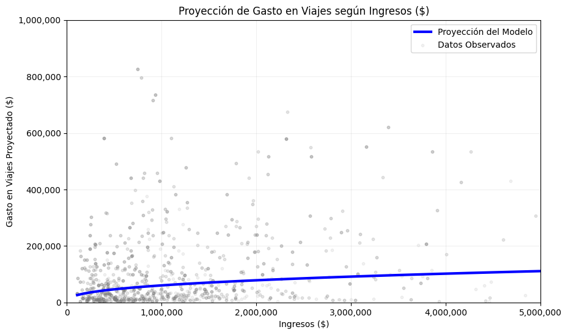

```python
ing_range = np.linspace(tabla_gasto['ing_pc'].min(), tabla_gasto['ing_pc'].max(), 100)
log_ing_range = np.log(ing_range + 1)
data_proyeccion = pd.DataFrame({
    'log_ing_pc': log_ing_range,
    'edad': tabla_gasto['edad'].mean(),
    'npersonas': tabla_gasto['npersonas'].median(),
    'sexo_lbl': tabla_gasto['sexo_lbl'].mode()[0],
    'grupo_escolaridad': 'Universitaria',
    'estrato_muestreo': tabla_gasto['estrato_muestreo'].mode()[0]
})

# Se calcula el gasto proyectado, prediciendo como log(gasto) y luego con exp() se retorna a pesos
pred_log = modelo_lineal.predict(data_proyeccion)
gasto_proyectado = np.exp(pred_log) - 1

plt.figure(figsize=(10, 6))
plt.plot(ing_range, gasto_proyectado, color='blue', lw=3, label='Proyección del Modelo')
plt.scatter(tabla_gasto['ing_pc'], tabla_gasto['gasto_viajes'], alpha=0.1, color='gray', s=10, label='Datos Observados')
plt.gca().xaxis.set_major_formatter(ticker.FuncFormatter(lambda x, p: format(int(x), ',')))
plt.gca().yaxis.set_major_formatter(ticker.FuncFormatter(lambda x, p: format(int(x), ',')))

plt.title('Proyección de Gasto en Viajes según Ingresos ($)')
plt.xlabel('Ingresos ($)')
plt.ylabel('Gasto en Viajes Proyectado ($)')
plt.xlim(0, 5000000) # Limitamos para ver mejor la zona densa
plt.ylim(0, 1000000)
plt.grid(True, alpha=0.2)
plt.legend()
plt.show()
```

Si bien el ajuste dista mucho de uno deseable para una RLM, hay que recordar que se está trabajando con datos de una encuesta en el cual la variabilidad de los datos de persona a persona es relevante. Además, en este sentido de analizar comportamiento humano, también hay que considerar que el fenómeno en sí analizado (gastos en viajes) no es algo transversal en la población. De hecho, a continuación se procede a analizar el comportamiento en la zona de estudio (Gran Santiago):

```python
def calcular_demanda(df, prob_col="prob_predicha"):
    """Aplica el modelo lineal (monto condicional) y combina con la
    probabilidad de incidencia ya calculada en `prob_col`.
    """
    df = df.copy()
    df["log_gasto_pred"] = modelo_lineal.predict(df)
    df["gasto_pred"] = np.exp(df["log_gasto_pred"]) - 1
    tope = tabla_gasto["gasto_viajes"].quantile(0.999)
    df["gasto_pred_wins"] = df["gasto_pred"].clip(upper=tope)

    df["demanda_ind"] = df[prob_col] * df["gasto_pred_wins"]
    return df

def pesos_por_persona(seed, codigos, celda_a_personas):
    dims = [[i] for i in range(len(codigos["objetivos"]))]
    IPF = ipfn.ipfn(seed.copy(), codigos["objetivos"], dims, convergence_rate=1e-6, max_iteration=50)
    tabla_reponderada = IPF.iteration()
    peso_celda = tabla_reponderada[codigos["indices"]]
    return peso_celda / celda_a_personas

def integerise_trs(pesos, rng):
    parte_entera = np.floor(pesos).astype(int)
    parte_fraccionaria = pesos - parte_entera
    idx = np.arange(len(pesos))
    replicados = np.repeat(idx, parte_entera)
    n_total = int(round(pesos.sum()))
    n_faltante = n_total - parte_entera.sum()
    if n_faltante > 0 and parte_fraccionaria.sum() > 0:
        probs = parte_fraccionaria / parte_fraccionaria.sum()
        extra = rng.choice(idx, size=n_faltante, replace=True, p=probs)
        replicados = np.concatenate([replicados, extra])
    return replicados
```

```python
# En este apartado es que se definen variables así la zona de estudio (Gran Santiago)
casen_raw = pyreadr.read_r(RUTA_CASEN)
casen_raw = casen_raw[list(casen_raw.keys())[0]]

vars_casen = ["estrato", "esc", "e6a", "edad", "sexo",
              "v13", "v13_propia", "v13_arrendada", "v13_cedida", "ypc"]
casen = casen_raw[vars_casen].copy()
casen["comuna"] = (casen["estrato"] // 100).astype("Int64")
casen = casen.drop(columns="estrato")

falta_esc = casen["esc"].isna()
modelo_esc = LinearRegression().fit(
    casen.loc[~falta_esc, ["e6a"]], casen.loc[~falta_esc, "esc"]
)
pred = modelo_esc.predict(casen.loc[falta_esc, ["e6a"]])
casen.loc[falta_esc, "esc"] = np.clip(np.round(pred), 0, 29)

casen = casen[~casen["ypc"].isna()].reset_index(drop=True)

# Acá se recodifican las variables entre EPF y CASEN
casen["grupo_escolaridad"] = pd.cut(
    casen["esc"], bins=[-np.inf, 12, 14, 16, np.inf],
    labels=["Escolar", "Tecnico", "Universitaria", "Postgrado"],
)
casen["rango_edad"] = pd.cut(
    casen["edad"], bins=[-1, 29, 44, 64, np.inf],
    labels=["jovenes", "adultos_jovenes", "adultos", "adultos_mayores"],
)
casen["sexo_lbl"] = casen["sexo"].map({1: "Hombre", 2: "Mujer"})
casen["ing_pc"] = casen["ypc"]
# Además, dado que la Regresión ocupó dos variables que la CASEN no consideraba, se deben estas añadir:
casen["log_ing_pc"] = np.log(casen["ing_pc"] + 1)
casen["npersonas"] = 1
casen["estrato_muestreo"] = 77

casen["prob_predicha" ] = modelo_logit.predict(casen)
casen = calcular_demanda(casen)

# La zona de estudio incluye comunas que no son de una misma Provincia, por lo que se agregan de forma separada:
censo_zonal = gpd.read_parquet(RUTA_CENSO_ZONAL).rename_geometry("geometry")
es_gran_santiago = (censo_zonal["PROVINCIA"] == "SANTIAGO") | (
    censo_zonal["COMUNA"].isin(['SAN BERNARDO', 'PUENTE ALTO', 'PIRQUE', 'PADRE HURTADO'])
)
censo_zonal = censo_zonal[es_gran_santiago].reset_index(drop=True)

censo_comunal = gpd.read_parquet(
    RUTA_CENSO_ZONAL.replace("_Zonal", "_Comunal")
).rename_geometry("geometry")
censo_comunal = censo_comunal[
    (censo_comunal["PROVINCIA"] == "SANTIAGO") | (censo_comunal["COMUNA"].isin(['SAN BERNARDO', 'PUENTE ALTO', 'PIRQUE', 'PADRE HURTADO']))
].reset_index(drop=True)

comunas_gs = censo_zonal["CUT"].unique()
casen = casen[casen["comuna"].isin(comunas_gs)].reset_index(drop=True)

print(f"Zonas censales en Gran Santiago: {len(censo_zonal)}")
print(f"Personas CASEN en Gran Santiago: {len(casen)}")
print(casen[["grupo_escolaridad", "rango_edad", "sexo_lbl", "prob_predicha", "demanda_ind"]].head())
```

```
Zonas censales en Gran Santiago: 1658
Personas CASEN en Gran Santiago: 32923
  grupo_escolaridad rango_edad sexo_lbl  prob_predicha  demanda_ind
0           Escolar    adultos    Mujer       0.078643  3533.039957
1           Escolar    jovenes    Mujer       0.104008  4793.120791
2         Postgrado    jovenes    Mujer       0.200506  8679.295355
3           Escolar    jovenes    Mujer       0.114352  5316.512009
4           Escolar    adultos   Hombre       0.071292  3194.155992
```

Lo arrojado en el último apartado, nos muestra con cuántas personas se modelará el comportamiento espacial (generadas por la microsimulación luego). También, resulta interesante observar que las mujeres jóvenes y con altos niveles educacionales son un segmento con una probabilidad de incurrir en gasto mayor que el quienes pueden tener niveles educacionales más bajos.

Luego se debe hacer calzar el Censo con la Casen, debiendo renombrar las columnas:

```python
COLS_SEXO = {"hombre": "n_hombres", "mujer": "n_mujeres"}
COLS_EDAD = {
    "edad_0_5": "n_edad_0_5", "edad_6_13": "n_edad_6_13", "edad_14_17": "n_edad_14_17",
    "edad_18_24": "n_edad_18_24", "edad_25_44": "n_edad_25_44",
    "edad_45_59": "n_edad_45_59", "edad_60_mas": "n_edad_60_mas",
}
COLS_EDUC = ["educ_nunca", "educ_primaria", "educ_secundaria", "educ_terciaria"]
COLS_TENENCIA = {
    "ten_propia_pagada": "n_tenencia_propia_pagada",
    "ten_propia_pagandose": "n_tenencia_propia_pagandose",
    "ten_arrendada_contrato": "n_tenencia_arrendada_contrato",
    "ten_arrendada_sin_contrato": "n_tenencia_arrendada_sin_contrato",
    "ten_cedida_trabajo": "n_tenencia_cedida_trabajo",
    "ten_cedida_familiar": "n_tenencia_cedida_familiar",
    "ten_otro": "n_tenencia_otro",
}

casen["sexo_cat"] = casen["sexo"].map({1: "hombre", 2: "mujer"})
casen["edad_cat"] = pd.cut(
    casen["edad"], bins=[0, 6, 14, 18, 25, 45, 60, np.inf],
    labels=list(COLS_EDAD.keys()), right=False, include_lowest=True,
).astype(str)
casen["educ_cat"] = pd.cut(
    casen["esc"], bins=[-1, 0, 8, 12, np.inf], labels=COLS_EDUC,
).astype(str)

condiciones = [
    (casen["v13"] == 1) & (casen["v13_propia"] == 1),
    (casen["v13"] == 1) & (casen["v13_propia"] == 2),
    (casen["v13"] == 2) & (casen["v13_arrendada"] == 5),
    (casen["v13"] == 2) & (casen["v13_arrendada"] == 6),
    (casen["v13"] == 3) & (casen["v13_cedida"] == 7),
    (casen["v13"] == 3) & (casen["v13_cedida"] == 8),
]
categorias_tenencia = [
    "ten_propia_pagada", "ten_propia_pagandose",
    "ten_arrendada_contrato", "ten_arrendada_sin_contrato",
    "ten_cedida_trabajo", "ten_cedida_familiar",
]
casen["tenencia_cat"] = np.select(condiciones, categorias_tenencia, default="ten_otro")

ZONA_ID = "OBJECTID"
constraints = censo_zonal[[ZONA_ID, "CUT", "COMUNA", "n_per", "n_hog"]].copy()
for nombre, col in {**COLS_SEXO, **COLS_EDAD}.items():
    constraints[nombre] = censo_zonal[col]
constraints["educ_nunca"] = censo_zonal["n_cine_nunca_curso_primera_infancia"]
constraints["educ_primaria"] = censo_zonal["n_cine_primaria"] + censo_zonal["n_cine_especial_diferencial"]
constraints["educ_secundaria"] = censo_zonal["n_cine_secundaria"]
constraints["educ_terciaria"] = censo_zonal["n_cine_terciaria_maestria_doctorado"]
personas_por_hogar = np.where(censo_zonal["n_hog"] > 0, censo_zonal["n_per"] / censo_zonal["n_hog"], 0)
for nombre, col in COLS_TENENCIA.items():
    constraints[nombre] = censo_zonal[col] * personas_por_hogar

CATEGORIAS = {
    "sexo_cat": list(COLS_SEXO.keys()),
    "edad_cat": list(COLS_EDAD.keys()),
    "educ_cat": COLS_EDUC,
    "tenencia_cat": list(COLS_TENENCIA.keys()),
}
constraints = constraints.set_index(ZONA_ID)
```

Finalmente se microsimula por IPF:

```python
rng = np.random.default_rng(SEED)
VARS_CONSTRAINT = list(CATEGORIAS.keys())

resultados_zona = []
buffer_salida = io.StringIO()
with contextlib.redirect_stdout(buffer_salida), warnings.catch_warnings():
    warnings.simplefilter("ignore", RuntimeWarning)

    for comuna_cut, cons_comuna in constraints.groupby("CUT"):
        muestra_comuna = casen[casen["comuna"] == comuna_cut]
        if len(muestra_comuna) == 0:
            continue

        indices = {
            var: pd.Categorical(muestra_comuna[var], categories=CATEGORIAS[var]).codes
            for var in VARS_CONSTRAINT
        }
        forma = tuple(len(CATEGORIAS[var]) for var in VARS_CONSTRAINT)
        seed_tabla = np.zeros(forma)
        indices_tupla = tuple(indices[var] for var in VARS_CONSTRAINT)
        np.add.at(seed_tabla, indices_tupla, 1)
        celda_a_personas = seed_tabla[indices_tupla]

        demanda_ind_comuna = muestra_comuna["demanda_ind"].to_numpy()
        ypc_comuna = muestra_comuna["ypc"].to_numpy()

        for zona_id, fila in cons_comuna.iterrows():
            if fila["n_per"] == 0:
                continue

            objetivos = [
                np.array([fila[cat] for cat in CATEGORIAS[var]], dtype=float)
                for var in VARS_CONSTRAINT
            ]
            pesos = pesos_por_persona(seed_tabla, {"objetivos": objetivos, "indices": indices_tupla}, celda_a_personas)
            sinteticos_idx = integerise_trs(pesos, rng)

            demanda_sintetica = demanda_ind_comuna[sinteticos_idx]

            resultados_zona.append({
                "zona_id": zona_id,
                "CUT": comuna_cut,
                "n_sintetico": len(sinteticos_idx),
                "n_censo": fila["n_per"],
                "demanda_total": demanda_sintetica.sum(),
                "demanda_percap": demanda_sintetica.mean() if len(demanda_sintetica) else np.nan,
            })

resultados_zona = pd.DataFrame(resultados_zona).set_index("zona_id")
print(f"Zonas simuladas: {len(resultados_zona)}")
resultados_zona.head()
```

```
Zonas simuladas: 1656
```

| zona_id | CUT | n_sintetico | n_censo | demanda_total | demanda_percap |
| --- | --- | --- | --- | --- | --- |
| 4309 | 13101 | 3918 | 3923.0 | 2.129690e+07 | 5435.655360 |
| 4310 | 13101 | 6245 | 6250.0 | 3.551177e+07 | 5686.431674 |
| 4311 | 13101 | 4038 | 4038.0 | 2.644484e+07 | 6548.994133 |
| 4312 | 13101 | 3050 | 3050.0 | 1.826479e+07 | 5988.455959 |
| 4313 | 13101 | 5597 | 5599.0 | 4.088281e+07 | 7304.415304 |

La muestra de la tabla anterior muestra un ejemplo de la cantidad de personas simuladas por zona censal junto con la demanda ($), por tanto, de cada una de estas. En base a este resultado es que se puede visualizar el comportamiento de los gastos presupuestados (demanda) a lo largo del Gran Santiago:

[figure not shown]

```python
# Por último se grafica la microsimulación en el área de estudio con el siguiente mapa:

# MAPA DE MICROSIMULACIÓN
zonas_mapa = censo_zonal.set_index(ZONA_ID).join(resultados_zona[["demanda_percap"]])
if zonas_mapa.crs is None:
    zonas_mapa.set_crs(epsg=4326, inplace=True)

fig, ax = plt.subplots(figsize=(12, 12))
zonas_mapa.plot(
    column="demanda_percap",
    cmap="Blues",
    linewidth=0.3,
    edgecolor="white",
    alpha=0.85,
    legend=True,
    legend_kwds={'label': "Demanda estimada ($)", 'shrink': 0.8},
    missing_kwds={"color": "lightgrey", "label": "sin dato"},
    ax=ax,
)

# Límites y etiquetas de comunas:
comunas_limites = censo_zonal.dissolve(by='COMUNA')
comunas_limites.boundary.plot(ax=ax, color='black', linewidth=1.35, alpha=0.8)
for comuna, fila in comunas_limites.iterrows():
    punto = fila.geometry.representative_point()
    ax.annotate(
        comuna.title(),
        xy=(punto.x, punto.y),
        ha="center",
        va="center",
        fontsize=9,
        fontweight='bold',
        color="black",
        path_effects=[pe.withStroke(linewidth=2, foreground="white")]
    )

# Grilla y Flecha Norte:
ax.grid(True, linestyle='--', alpha=0.5, color='gray')
ax.set_axis_on()
ax.tick_params(labelsize=13)
ax.set_xlabel("Longitud", fontsize=18)
ax.set_ylabel("Latitud", fontsize=18)
x, y, arrow_length = 0.08, 0.95, 0.08
ax.annotate('N', xy=(x, y), xytext=(x, y - arrow_length),
            arrowprops=dict(facecolor='black', width=5, headwidth=15),
            ha='center', va='center', fontsize=20,
            xycoords=ax.transAxes)

cx.add_basemap(ax, crs=zonas_mapa.crs.to_string(), source=cx.providers.CartoDB.Positron) # Acá se añade un mapa base

ax.set_title("Estimación de la Demanda por Paquetes Turísticos y Viajes Aéreos\n--GRAN SANTIAGO--\nCENSO 2024 - CASEN 2024 - IX EPF 2022", fontsize=14)
plt.show()
```

Del resultado anterior se puede establecer que los sectores del Gran Santiago donde mayor es la demanda estimada por el servicio de compra de paquetes turísticos y viajes aéreos (esto dado por su mayor nivel de presupuesto destinado para tales gastos) son las comunas del sector oriente (Lo Barnechea, Vitacura, Las Condes, La Reina, Ñuñoa y Providencia). A partir de esto, es que en el presente estudio se enfocará a continuación en la oferta de este servicio en dichas comunas solamente, dado que son donde mayor benedficio puede redituarle a las empresas involucradas en el rubro.

En este sentido, para la espacialización de la oferta se procedió al uso de archivos de tipo "geojson" con los cuales es posible plasmar en la zona de estudio isocronas alrededor de los puntos de oferta del servicio analizado.

```python
# Se cargan los archivos:
viajes = gpd.read_file("../DATA/tf/viajes.geojson")
comunas = gpd.read_file("../DATA/tf/censo_comunal.geojson")
ze_zonal = gpd.read_file("../DATA/tf/zonaestudio_zonal.geojson")
```

[figure not shown]

```python
# Visualización de la zona de estudio y los puntos de venta (oferta) en ésta:
fig, (ax1, ax2) = plt.subplots(1, 2, figsize=(20, 10))
ze_zonal_3857 = ze_zonal.to_crs(epsg=3857)
viajes_3857 = viajes.to_crs(epsg=3857)

# Mapa 1: Zona de Estudio
ze_zonal_3857.plot(ax=ax1, edgecolor='white', alpha=0.8)
ax1.set_title("Zona de Estudio")

# Mapa 2: Oferta
viajes_3857.plot(ax=ax2, color='red', markersize=135, edgecolor='black')
ze_zonal_3857.boundary.plot(ax=ax2, color='black', linewidth=0.8)
ax2.set_title("Puntos de Venta de Paquetes Turísticos & Viajes Aéreos")

def add_map_details(ax):
    ax.grid(True, linestyle='--', alpha=0.6)
    cx.add_basemap(ax, source=cx.providers.CartoDB.Positron)              # Acá se añade un mapa base
    x, y, arrow_length = 0.05, 0.95, 0.07
    ax.annotate('N', xy=(x, y), xytext=(x, y - arrow_length),
                arrowprops=dict(facecolor='black', width=3, headwidth=10),
                ha='center', va='center', fontsize=15,
                xycoords=ax.transAxes)

add_map_details(ax1)
add_map_details(ax2)

plt.tight_layout()
plt.show()
```

Lo anterior nos muestra dónde es que se encuentran actualmente los puntos de venta físicos de paquetes turísticos y viajes aéreos en la zona estudiada, evidenciándose que estas se tienden a concentrar en entornos comerciales (sector Tobalaba - El Golf; Parque Araucano; Mall Alto las Condes). Cabe destacar que estos puntos de venta corresponden a las principales compañías del rubro que disponen de locales, siendo estos LATAM Airlines Travel, COCHA, Viajes Falabella y Turavión. También se cuentan con puntos de venta en La Reina y Ñuñoa, ambos también dentro de recintos comerciales.

En paralelo, también se crea la red vial para la creación de las isocronas:

```python
# Crear buffer de 1000 metros alrededor del polígono comunal
# Reproyectar a un CRS proyectado (e.g., UTM) antes de aplicar el buffer
comunas_proj = comunas.to_crs(comunas.estimate_utm_crs())

buffer_comunal_proj_buffered = comunas_proj.buffer(10000)

# Reproyectar el polígono buffer de vuelta a EPSG:4326 para osmnx
buffer_comuna = buffer_comunal_proj_buffered.to_crs("EPSG:4326").iloc[0]
```

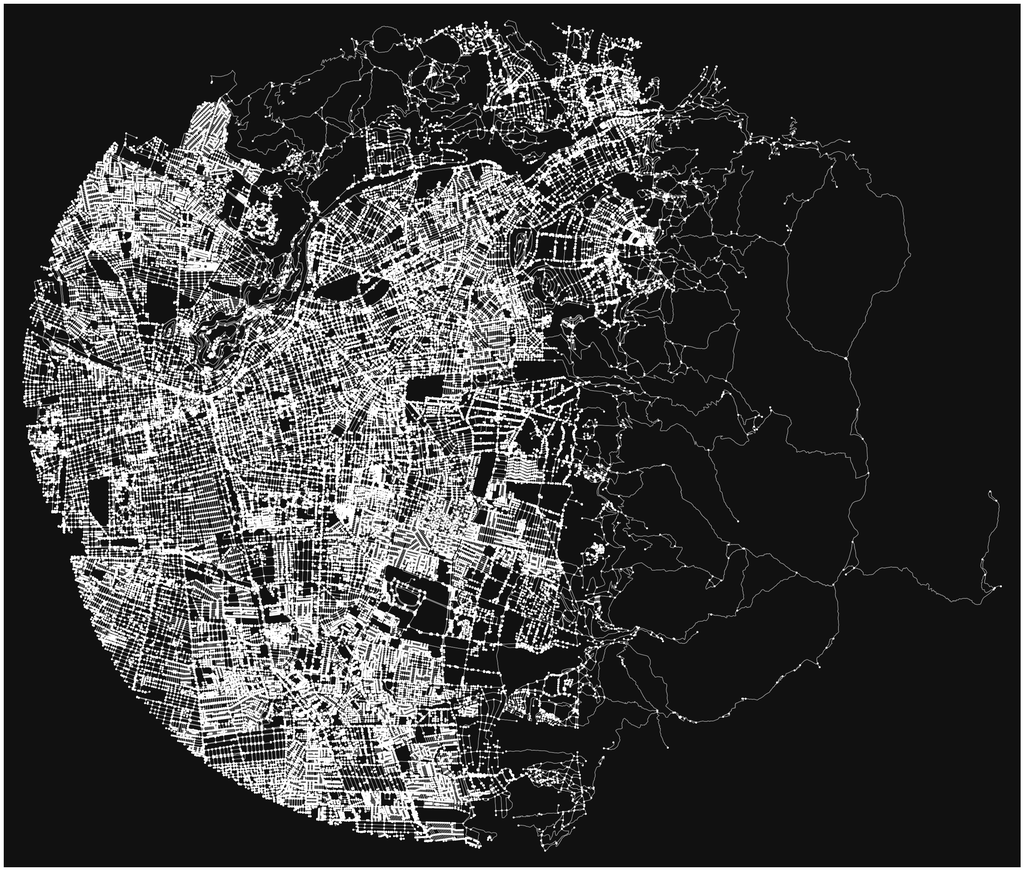

```
(<Figure size 3500x3500 with 1 Axes>, <Axes: >)
```

```python
# Descargar red vial para caminata
G = ox.graph_from_polygon(buffer_comuna, network_type='walk')

# Asignar velocidad de caminata y calcular tiempo de viaje
ox.settings.default_speed_walk = 5
for u, v, k, data in G.edges(keys=True, data=True):
    data['speed_kph'] = 5
G = ox.add_edge_travel_times(G)

# Visualizar grafo con mayor tamaño
ox.plot_graph(G, figsize=(35, 35))
```

```python
# Convertir todos los puntos de venta a WGS84
viajes = viajes.to_crs("4326")

# Inicializar set de nodos accesibles
todos_nodos_iso = set()

# Recorrer todos los minimarkets y acumular nodos accesibles
for idx, row in viajes.iterrows():
    punto = row.geometry
    try:
        origen = ox.nearest_nodes(G, punto.x, punto.y)
        subgraph = nx.ego_graph(G, origen, radius=900, distance='travel_time')
        nodos_iso = list(subgraph.nodes)
        todos_nodos_iso.update(nodos_iso)
    except Exception as e:
        print(f"Error en puntos de venta físicos {idx}: {e}")

nodos_geom = [Point((G.nodes[n]['x'], G.nodes[n]['y'])) for n in todos_nodos_iso]
gdf_iso_all = gpd.GeoDataFrame(geometry=nodos_geom, crs="EPSG:4326")
```

[figure not shown]

```python
fig, (ax1, ax2) = plt.subplots(1, 2, figsize=(22, 10))

# MAPA 1: ISÓCRONAS:
ze_zonal_3857 = ze_zonal.to_crs(epsg=3857)
gdf_iso_all_3857 = gdf_iso_all.to_crs(epsg=3857)
viajes_3857 = viajes.to_crs(epsg=3857)

ze_zonal_3857.plot(ax=ax1, color='none', edgecolor='black', linewidth=0.8)
gdf_iso_all_3857.plot(ax=ax1, color='blue', markersize=2, alpha=0.8, label='Nodos Accesibles')
viajes_3857.plot(ax=ax1, color='red', markersize=135, label='Puntos de Venta')
ax1.set_title("Puntos de Venta con sus Isócronas)", fontsize=14)

# MAPA 2: COBERTURA:
isocrona_area = gdf_iso_all.union_all().convex_hull
isocrona_area_proj = gpd.GeoSeries([isocrona_area], crs="EPSG:4326").to_crs(ze_zonal.crs).geometry.iloc[0]
ze_zonal['centroide'] = ze_zonal.geometry.centroid
ze_zonal['cobertura_centroide'] = ze_zonal['centroide'].within(isocrona_area_proj)


ze_zonal_3857.plot(ax=ax2, column='cobertura_centroide', categorical=True, legend=True,
                   cmap='Paired', alpha=0.6, edgecolor='white', linewidth=0.3)

isocrona_area_3857 = gpd.GeoSeries([isocrona_area], crs="EPSG:4326").to_crs(epsg=3857)
isocrona_area_3857.plot(ax=ax2, color='lightblue', alpha=0.8, edgecolor='blue', linestyle='--')
viajes_3857.plot(ax=ax2, color='red', markersize=135)
ax2.set_title("Zonas Cubiertas según Centroide", fontsize=14)

# GRILLA, FLECHA NORTE
def decorar_mapa(ax):
    cx.add_basemap(ax, source=cx.providers.CartoDB.Positron)             # Acá se añade un mapa base
    ax.grid(True, linestyle='--', alpha=0.5, color='gray')
    x, y, arrow_length = 0.05, 0.95, 0.07
    ax.annotate('N', xy=(x, y), xytext=(x, y - arrow_length),
                arrowprops=dict(facecolor='black', width=3, headwidth=10),
                ha='center', va='center', fontsize=16, fontweight='bold',
                xycoords=ax.transAxes)

decorar_mapa(ax1)
decorar_mapa(ax2)

plt.tight_layout()
plt.show()
```

Los mapas resultantes nos muestran la cobertura de los puntos de venta físico de paquetes turísticos y viajes aéreos, considerando eso sí, según un radio de cobertura en base a las posibilidades de una caminata de 15 minutos por la red vial de la zona de estudio. Esta consideración obviamente puede ser modificado para una cobertura en base a un recorrido en automóvil o por transporte público, pero esta vez corresponde a caminata tomando en cuenta de que los entornos en donde se ubican los puntos de venta son sectores del Gran Santiago que se caracterizan por una mejor infraestructura para el peatón (veredas en buen estado, señalización, etc.), accesibilidad con transporte público, y un nivel de seguridad que no restringen a una persona el hacer caminatas más largas (en comparación al resto del Gran Santiago).

Destacan así los alrededores de los Metro Tobalaba y Plaza Egaña, del Parque Araucano, del Parque Intercomunal La Reina y del Mall Alto Las Condes como donde más cobertura del servicio estudiado existe. Es así que en general, la comuna de Las Condes es la más beneficiada versus el resto de las comunas estudiadas.

A continuación se muestra el mapa anterior de las zonas cubiertas (oferta) junto con el primer mapa realizado sobre el nivel de demanda por zona censal, esta vez eso sí, dejando sólo las correspondientes a las comunas de estudio:

[figure not shown]

```python
fig, (ax1, ax2) = plt.subplots(1, 2, figsize=(24, 12))

# Para el 1er mapa se filtra por las comunas de interés:
comunas_interes_nombres = ["LO BARNECHEA", "VITACURA", "LAS CONDES", "PROVIDENCIA", "ÑUÑOA", "LA REINA"]
comunas_interes_cut = censo_comunal[censo_comunal["COMUNA"].isin(comunas_interes_nombres)]['CUT'].unique()
censo_zonal_filtrado = censo_zonal[censo_zonal['CUT'].isin(comunas_interes_cut)]
resultados_zona_filtrado = resultados_zona[resultados_zona['CUT'].isin(comunas_interes_cut)]
zonas_mapa_filtrado = censo_zonal_filtrado.set_index(ZONA_ID).join(resultados_zona_filtrado[["demanda_percap"]])

if zonas_mapa_filtrado.crs is None:
    zonas_mapa_filtrado.set_crs(epsg=4326, inplace=True)

zonas_mapa_filtrado.plot(
    column="demanda_percap",
    cmap="Blues",
    linewidth=0.5,
    edgecolor="white",
    alpha=0.85,
    legend=True,
    legend_kwds={'label': "Demanda estimada ($)", 'shrink': 0.8},
    missing_kwds={"color": "lightgrey", "label": "sin dato"},
    ax=ax1,
)

# Límites y etiquetas de comunas:
comunas_limites_filtrado = censo_zonal_filtrado.dissolve(by='COMUNA')
comunas_limites_filtrado.boundary.plot(ax=ax1, color='black', linewidth=1.8, alpha=0.8)
for comuna, fila in comunas_limites_filtrado.iterrows():
    punto = fila.geometry.representative_point()
    ax1.annotate(
        comuna.title(),
        xy=(punto.x, punto.y),
        ha="center",
        va="center",
        fontsize=13,
        fontweight='bold',
        color="black",
        path_effects=[pe.withStroke(linewidth=2, foreground="white")]
    )

# Grilla y Flecha Norte para el Mapa 1:
ax1.grid(True, linestyle='--', alpha=0.5, color='gray')
ax1.set_axis_on()
ax1.tick_params(labelsize=13)
ax1.set_xlabel("Longitud", fontsize=18)
ax1.set_ylabel("Latitud", fontsize=18)
x, y, arrow_length = 0.08, 0.95, 0.08
ax1.annotate('N', xy=(x, y), xytext=(x, y - arrow_length),
            arrowprops=dict(facecolor='black', width=5, headwidth=15),
            ha='center', va='center', fontsize=20,
            xycoords=ax1.transAxes)

cx.add_basemap(ax1, crs=zonas_mapa_filtrado.crs.to_string(), source=cx.providers.CartoDB.Positron)
ax1.set_title("Estimación de la Demanda por Paquetes Turísticos y Viajes Aéreos\n(Comunas seleccionadas)\nCENSO 2024 - CASEN 2024 - IX EPF 2022", fontsize=14)


# El 2do mapa es la repetición del anterior bloque:

def complementos_mapa(ax):
    cx.add_basemap(ax, source=cx.providers.CartoDB.Positron) # Acá se añade un mapa base
    ax.grid(True, linestyle='--', alpha=0.5, color='gray')
    x, y, arrow_length = 0.05, 0.95, 0.07
    ax.annotate('N', xy=(x, y), xytext=(x, y - arrow_length),
                arrowprops=dict(facecolor='black', width=3, headwidth=10),
                ha='center', va='center', fontsize=16, fontweight='bold',
                xycoords=ax.transAxes)

ze_zonal_3857 = ze_zonal.to_crs(epsg=3857)
viajes_3857 = viajes.to_crs(epsg=3857)

# Calcular la isocrona_area y cobertura_centroide de nuevo, asegurando la coherencia
isocrona_area = gdf_iso_all.unary_union.convex_hull
isocrona_area_proj = gpd.GeoSeries([isocrona_area], crs="EPSG:4326").to_crs(ze_zonal.crs).geometry.iloc[0]
ze_zonal_proj_for_centroid = ze_zonal.to_crs(ze_zonal.estimate_utm_crs())
ze_zonal['centroide'] = ze_zonal_proj_for_centroid.geometry.centroid.to_crs(ze_zonal.crs)

ze_zonal['cobertura_centroide'] = ze_zonal['centroide'].within(isocrona_area_proj)
ze_zonal_3857.plot(ax=ax2, column='cobertura_centroide', categorical=True, legend=True,
                   cmap='Paired', alpha=0.6, edgecolor='white', linewidth=0.3)

isocrona_area_3857 = gpd.GeoSeries([isocrona_area], crs="EPSG:4326").to_crs(epsg=3857)
isocrona_area_3857.plot(ax=ax2, color='lightblue', alpha=0.8, edgecolor='blue', linestyle='--')
viajes_3857.plot(ax=ax2, color='red', markersize=135)
ax2.set_title("Zonas Cubiertas según Centroide", fontsize=14)

complementos_mapa(ax2)

plt.tight_layout()
plt.show()
```

La cobertura de los servicios ya está descrita, y esta se concentra en la comuna de Las Condes por el eje de la Avenida Kennedy y Apoquindo hacia su borde connla comuna de Providencia. Por otro lado, y xomo se puede observar a un costado, estas no son precisamente las áreas donde existiría una mayor demanda estimada por el servicio de venta de paquetes turísticos y viajes áereos: estas en rigor corresponde a la comuna de Vitacura. Y aunque el eje de la Avenida Kennedy es también límite de la comuna de Vitacura, se puede ver que el trasapaso de la cobertura desde Las Condes hacia Vitacura no es significativo. Esto se puede estimar como a causa de que dicho eje corresponde a una Autopista, por lo cual el atravieso de esta de forma peatonal es muy dificultoso, actuando como una barrera para los potenciales clientes de Vitacura, por lo que se estima que dicha comuna no está completamente cubierta por la oferta respecto a la demanada existente.

[figure not shown]

```python
# Grado de cobertura (oferta/demanda):

mapa_tasa_cobertura = ze_zonal.copy()
mapa_tasa_cobertura['covered_geometry'] = mapa_tasa_cobertura.geometry.intersection(isocrona_area_proj)
mapa_tasa_cobertura['covered_area_sqm'] = mapa_tasa_cobertura['covered_geometry'].area
mapa_tasa_cobertura['total_area_sqm'] = mapa_tasa_cobertura.geometry.area

# Se calcula el % de cobertura (Oferta)
# Manejar divisiones por cero o NaN resultantes de zonas con área 0
with np.errstate(divide='ignore', invalid='ignore'): # Suprimir warnings de división por cero/NaN
    mapa_tasa_cobertura['cobertura_porcentaje'] = (mapa_tasa_cobertura['covered_area_sqm'] / mapa_tasa_cobertura['total_area_sqm']) * 100
mapa_tasa_cobertura['cobertura_porcentaje'] = mapa_tasa_cobertura['cobertura_porcentaje'].replace([np.inf, -np.inf], np.nan).fillna(0)
mapa_tasa_cobertura = mapa_tasa_cobertura.set_index('OBJECTID').join(resultados_zona[['demanda_percap']])
mapa_tasa_cobertura_filtrado = mapa_tasa_cobertura[
    mapa_tasa_cobertura['demanda_percap'].notna() & (mapa_tasa_cobertura['demanda_percap'] > 0)
].copy()

with np.errstate(divide='ignore', invalid='ignore'): # Suprimir warnings de división por cero/NaN
    mapa_tasa_cobertura_filtrado['tasa_de_cobertura'] = (
        mapa_tasa_cobertura_filtrado['cobertura_porcentaje'] / mapa_tasa_cobertura_filtrado['demanda_percap']
    )

mapa_tasa_cobertura_filtrado.replace([np.inf, -np.inf], np.nan, inplace=True)

# Mapa Índice oferta/demanda
fig, ax = plt.subplots(1, 1, figsize=(14, 14))

mapa_tasa_cobertura_filtrado.plot(
    column="tasa_de_cobertura",
    cmap="YlGnBu",
    linewidth=0.3,
    edgecolor="white",
    alpha=0.85,
    legend=True,
    legend_kwds={'label': "Tasa de Cobertura (Oferta % / Demanda $)", 'shrink': 0.8},
    missing_kwds={"color": "lightgrey", "label": "Sin Datos de Tasa"},
    ax=ax,
)

# Límites y etiquetas de comunas:
comunas_limites = ze_zonal.dissolve(by='COMUNA')
comunas_limites.boundary.plot(ax=ax, color='black', linewidth=1.35, alpha=0.8)
for comuna, fila in comunas_limites.iterrows():
    punto = fila.geometry.representative_point()
    ax.annotate(
        comuna.title(),
        xy=(punto.x, punto.y),
        ha="center",
        va="center",
        fontsize=9,
        fontweight='bold',
        color="black",
        path_effects=[pe.withStroke(linewidth=2, foreground="white")]
    )

# Grilla y Flecha Norte:
ax.grid(True, linestyle='--', alpha=0.5, color='gray')
ax.set_axis_on()
ax.tick_params(labelsize=13)
ax.set_xlabel("Longitud", fontsize=18)
ax.set_ylabel("Latitud", fontsize=18)
x, y, arrow_length = 0.08, 0.95, 0.08
ax.annotate('N', xy=(x, y), xytext=(x, y - arrow_length),
            arrowprops=dict(facecolor='black', width=5, headwidth=15),
            ha='center', va='center', fontsize=20,
            xycoords=ax.transAxes)

cx.add_basemap(ax, crs=mapa_tasa_cobertura_filtrado.crs.to_string(), source=cx.providers.CartoDB.Positron) # Acá se añade un mapa base

ax.set_title("Tasa de Cobertura del Servicio por Zona Censal\n(Oferta % de área cubierta / Demanda $ per cápita)", fontsize=16)
plt.show()
```

El Índice anterior sobre oferta/demanda, nos muestra dos situaciones a destacar. La primera, y más evidente, es la cantidad de sectores sin cobertura (Índice = 0) aún tratándose de ser las con mayor demanda estimada (esto según la cantidad de presupuesto destinado a este ítem). Por otro lado, se tiene como contraparte que la zona con mayor cobertura (al rededores del Country Club Príncipe de Gales) coincide también con una donde la demanda no es tan alta como en otros sectores. En rigor, esto viene de la fórmula matemática donde una zona con alta oferta y menor demanda tendrá un Índice mayor.

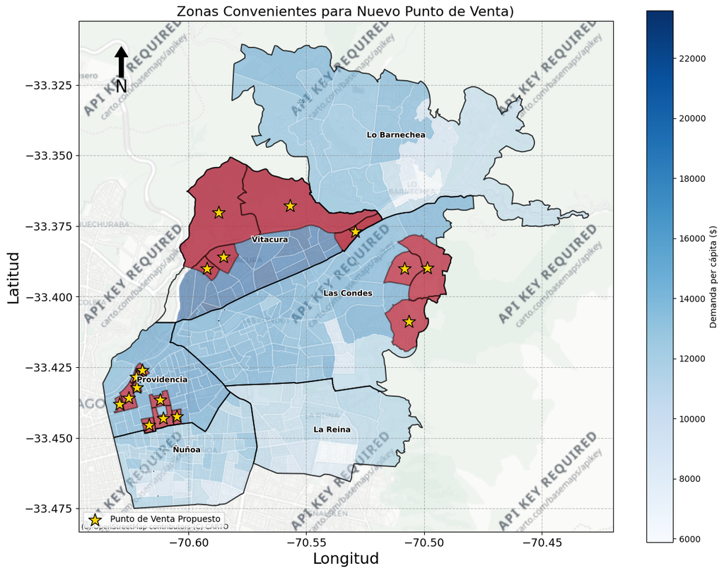

```python
# Para definir ubicaciones donde localizar un nuevo punto de venta:
# Primero se identifica las zonas con alta demanda y baja oferta
umbral_alta_demanda = mapa_tasa_cobertura_filtrado['demanda_percap'].quantile(0.75)
umbral_baja_oferta = 5

zonas_nula_oferta = mapa_tasa_cobertura_filtrado[
    (mapa_tasa_cobertura_filtrado['demanda_percap'] > umbral_alta_demanda) &
    (mapa_tasa_cobertura_filtrado['cobertura_porcentaje'] == 0)
].copy()

if zonas_nula_oferta.empty:
    zonas_identificadas = mapa_tasa_cobertura_filtrado[
        (mapa_tasa_cobertura_filtrado['demanda_percap'] > umbral_alta_demanda) &
        (mapa_tasa_cobertura_filtrado['cobertura_porcentaje'] <= umbral_baja_oferta)
    ].copy()
    titulo_oferta = f"Baja Cobertura (≤ {umbral_baja_oferta}%) (si no hay nula)"
else:
    zonas_identificadas = zonas_nula_oferta
    titulo_oferta = "Nula Cobertura (0%)"
if zonas_identificadas.empty:
    print("No se encontraron zonas que cumplan con los criterios de alta demanda y baja/nula oferta.")
else:
    zonas_identificadas_proj = zonas_identificadas.to_crs(zonas_identificadas.estimate_utm_crs())
    zonas_identificadas['punto_propuesta'] = zonas_identificadas_proj.geometry.centroid.to_crs(zonas_identificadas.crs)

    fig, ax = plt.subplots(1, 1, figsize=(14, 14))
    mapa_tasa_cobertura_filtrado.plot(
        column="demanda_percap",
        cmap="Blues",
        linewidth=0.5,
        edgecolor="white",
        alpha=0.5,
        legend=True,
        legend_kwds={'label': "Demanda per cápita ($)", 'shrink': 0.8},
        missing_kwds={"color": "lightgrey", "label": "Sin Datos de Demanda"},
        ax=ax,
        zorder=1
    )

    # Zonas censales convenientes:
    zonas_identificadas.plot(
        color="red", # En roja para resaltarlas
        edgecolor="black",
        linewidth=1.5,
        alpha=0.5,
        ax=ax,
        label=f"Zonas con Alta Demanda y {titulo_oferta}",
        zorder=2
    )

    # Puntos convenientes:
    zonas_identificadas.set_geometry('punto_propuesta').plot(
        ax=ax,
        marker='*', # Estrella para identificarlos
        color='gold',
        markersize=250,
        edgecolor='black',
        linewidth=1,
        label='Punto de Venta Propuesto',
        zorder=3
    )

    # Límites y etiquetas de comunas:
    comunas_limites = ze_zonal.dissolve(by='COMUNA')
    comunas_limites.boundary.plot(ax=ax, color='black', linewidth=1.35, alpha=0.8, zorder=4)
    for comuna, fila in comunas_limites.iterrows():
        punto = fila.geometry.representative_point()
        ax.annotate(
            comuna.title(),
            xy=(punto.x, punto.y),
            ha="center",
            va="center",
            fontsize=9,
            fontweight='bold',
            color="black",
            path_effects=[pe.withStroke(linewidth=2, foreground="white")],
            zorder=5
        )

    # Grilla y Flecha Norte
    ax.grid(True, linestyle='--', alpha=0.5, color='gray')
    ax.set_axis_on()
    ax.tick_params(labelsize=13)
    ax.set_xlabel("Longitud", fontsize=18)
    ax.set_ylabel("Latitud", fontsize=18)
    x, y, arrow_length = 0.08, 0.95, 0.08
    ax.annotate('N', xy=(x, y), xytext=(x, y - arrow_length),
                arrowprops=dict(facecolor='black', width=5, headwidth=15),
                ha='center', va='center', fontsize=20,
                xycoords=ax.transAxes)

    cx.add_basemap(ax, crs=mapa_tasa_cobertura_filtrado.crs.to_string(), source=cx.providers.CartoDB.Positron) # Acá se añade un mapa base

    ax.set_title(
        f"Zonas Convenientes para Nuevo Punto de Venta)",
        fontsize=16
    )
    ax.legend(loc='lower left')
    plt.show()
```

El anterior mapa propone zonas censales donde es conveniente localizar un nuevo punto de venta en base a que son zonas con alta demanda estimada por el servicio pero con poca o nula oferta del mismo.

No obstante, antes de decidirse por alguno, bien vale saber que no todos esos en rigor son tan convenientes de elegir. En otras palabras, si bien teóricamente estas zonas lo son, en rigor en la práctica su lejanía (sector San Carlos de Apoquindo) y/o su topografía (Santa María de Manquehue y Lo Currro) se estiman como motivos suficientes como para descartarlos, dado que estos factores no son comercialmente deseables.

Además, para decantarse por alguno(s) en concreto, hay que tomar en cuenta el perfil socioeconómico del sector de donde se ubicaría el nuevo punto de venta. Es así que a continuación se observa la variación del nivel educativo en el área de estudio. Esto, dado que se trata de un buen indicador que se condice con el nivel de estándar de vida de las personas (a mayor años de estudio, ya se vió que no sólo tienen mayor poder adquisitivo (ingresos), sino que derechamente terminan por tratarse de grupos de personas que tienden a destinar una mayor cantidad de su presupuesto para lo que es la compra de paquetes turísticos y viajes aéreos), siendo así un buen parámetro orientador de una localización conveniente, aún sin un modelo matemático (al igual que la consideración de los factores de lejanía y topografía sirven para orientar la decisión final).

```python
ze24_zonal = gpd.read_parquet(RUTA_CENSO_ZONAL)
# Acá se realiza un filtrado de toda la información regional para solo disponer de la información comunal deseada:
ze24 = (ze24_zonal["COMUNA"].isin(["LO BARNECHEA", "VITACURA", "LAS CONDES", "PROVIDENCIA", "ÑUÑOA", "LA REINA"])) # Puede ser que haya que cambiar de "" a ''

ze24c_zonal = ze24_zonal[ze24].reset_index(drop=True)
```

```python
porcentaje_estudio_2024 = (ze24c_zonal["n_cine_terciaria_maestria_doctorado"] / ze24c_zonal["n_per"]) * 100
años_estudio = ze24c_zonal["prom_escolaridad18"]
```

[figure not shown]

```python
# Comportamiento territorial educacional en el área de estudio:
def plot_univariado(ax, censo_zonal_z, censo_zonal_c, censo_zonal_ct, col, cmap, titulo, cbar_label):
    # Graficar datos con transparencia (alpha) para ver el mapa base
    censo_zonal_z.plot(
        column=col, ax=ax, cmap=cmap, linewidth=0, alpha=0.9,
        legend=True,
        legend_kwds={'label': cbar_label, 'shrink': 0.45, 'pad': 0.02}
    )
    # Dibujar límites de comunas
    censo_zonal_c.plot(ax=ax, facecolor='none', edgecolor='#111', linewidth=0.8)

    # Anotaciones de nombres de comunas
    for _, row in censo_zonal_ct.iterrows():
        ax.annotate(
            row.name,
            xy=(row.geometry.x, row.geometry.y),
            ha='center', va='center',
            fontsize=9, fontweight='bold', color='#111',
            bbox=dict(boxstyle='round,pad=0.2', fc='white', alpha=0.8, ec='none')
        )

    # Agregar mapa base contextual
    cx.add_basemap(ax, source=cx.providers.CartoDB.Positron)

    ax.set_title(titulo, fontsize=13, fontweight='bold', pad=10)
    ax.set_axis_off() # Ocultamos los ejes para mejorar la estética con el mapa base

# Preparación de datos y proyección a Web Mercator (EPSG:3857) para compatibilidad con basemaps
if 'SHAPE' in ze24c_zonal.columns:
    censo_zonal = ze24c_zonal.set_geometry('SHAPE').rename_geometry('geometry')

# Proyección necesaria para contextily
censo_zonal = censo_zonal.to_crs(epsg=3857)

censo_zonal['porcentaje_estudio_2024'] = porcentaje_estudio_2024
censo_zonal['años_estudio'] = años_estudio

censo_zonal_comunas = censo_zonal.dissolve(by='COMUNA')
censo_zonal_centroides = censo_zonal_comunas.copy()
censo_zonal_centroides.geometry = censo_zonal_comunas.geometry.centroid

fig, axes = plt.subplots(1, 2, figsize=(23, 20))
fig.patch.set_facecolor('#fafafa')

plot_univariado(
    axes[0], censo_zonal, censo_zonal_comunas, censo_zonal_centroides,
    'porcentaje_estudio_2024', 'bone_r',
    '% Personas con estudios superiores por zona censal - CENSO 2024',
    '% Personas con estudios superiores'
)

plot_univariado(
    axes[1], censo_zonal, censo_zonal_comunas, censo_zonal_centroides,
    'años_estudio', 'tab10',
    'Años de escolaridad - CENSO 2024',
    'Años de escolaridad'
)

plt.tight_layout(pad=2)
plt.show()
```

[figure not shown]

```python
# Finalmente, se priorizan las zonas más convenientes en Vitacura y Providencia

def obtener_top_puntos(comuna, n=2):
    return mapa_tasa_cobertura_filtrado[
        (mapa_tasa_cobertura_filtrado['COMUNA'] == comuna) &
        (mapa_tasa_cobertura_filtrado['cobertura_porcentaje'] == 0)
    ].sort_values('demanda_percap', ascending=False).head(n)

vitacura_top = obtener_top_puntos('VITACURA', 2)
providencia_top = obtener_top_puntos('PROVIDENCIA', 2)
propuesta_final = pd.concat([vitacura_top, providencia_top])

# Generar isócronas para los 4 puntos propuestos (impacto de la mejora)
def generar_isocrona(geom, grafo, radio=900):
    lat, lon = geom.centroid.y, geom.centroid.x
    origen = ox.nearest_nodes(grafo, lon, lat)
    subgraph = nx.ego_graph(grafo, origen, radius=radio, distance='travel_time')
    nodos_geom = [Point((grafo.nodes[n]['x'], grafo.nodes[n]['y'])) for n in subgraph.nodes]
    return gpd.GeoDataFrame(geometry=nodos_geom, crs="EPSG:4326").union_all().convex_hull

propuesta_final['isocrona'] = propuesta_final.geometry.apply(lambda g: generar_isocrona(g, G))
iso_area_total_prop = propuesta_final.set_geometry('isocrona').union_all()

fig, ax = plt.subplots(figsize=(12, 10))

ze_zonal.to_crs(epsg=3857).plot(ax=ax, color='white', edgecolor='black', alpha=0.2)
gpd.GeoSeries([isocrona_area], crs="4326").to_crs(3857).plot(ax=ax, color='blue', alpha=0.2, label='Cobertura Actual')
gpd.GeoSeries([iso_area_total_prop], crs="4326").to_crs(3857).plot(ax=ax, color='green', alpha=0.4, label='Nueva Cobertura Propuesta')

viajes.to_crs(3857).plot(ax=ax, color='red', markersize=60, label='Locales Actuales', zorder=5)
propuesta_final.to_crs(3857).plot(ax=ax, color='gold', marker='*', markersize=300, edgecolor='black', label='Propuesta)', zorder=6)

cx.add_basemap(ax, crs=3857, source=cx.providers.CartoDB.Positron)            # Acá se añade un mapa base
ax.set_title("Impacto: Mejora de Cobertura Propuesta en Vitacura y Providencia", fontsize=15)
ax.legend(loc='upper left')
ax.set_axis_off()

plt.tight_layout()
plt.show()
```

En el caso de instalarse en el sector de Estoril/Cantagallo (a la derecha del mapa), se condice con instalarlo derechamente en la zona censal donde hay una mayor demanda estimada, no pudiendo ser alcanzado por el punto de venta en el Alto Las Condes, sin embargo su radio de influencia no es considerablemente grande fundamentalmente debido a el entorno en el que se encuentra, es decir, limitado por la Autopista Costanera Norte, el Río Mapocho y el eje Kennnedy, lo que hace que para un peatón foráneo tal vez no le sea tan conveniente acudir hasta allá. No obstante habría que considerar que en esa zona durante los próximos años la red de Metro se extenderá hasta precisamente acá (Línea 7), por lo cual de todos modos tendría una atractividad esta elección debido al flujo de gente que pasaría por el lugar, incluso foráneos.

El caso de una instalación en el entorno de Américo Vespuecio, hay que considerar que la red de transporte público no es tan robusta, pero si que es un entorno donde las personas no presentarían muchos inconvenientes para transitar, esto dada la tranquilidad del sector.

Por último, el caso de la instalación en el sector de Providencia podría significar una oportunidad para relocalizar alguna sucursal de las que actualmente se concentra en el entorno del Metro Tobalaba. Si bien esta última zona alberga un gran flujo de personas, hoteles y centros comerciales, disponer de algún punto de venta más hacia el poniente según lo modelado sería conveniente, a tal punto incluso que se trataría de aquella opción con mayor cobertura, pudiendo incluso servir al sector norte de la comuna de Ñuñoa.

En definitiva, la opción final entre estas tres alternativas debe ser analizada prudentemente según ya sea lo mencionado (entorno, beneficios futuros, etc.), así como los requerimientos de la organización del rubro de venta de paquetes turísticos y viajes aéreos.

# Conclusiones

En base a los resultados obtenidos, es posible concluir que el área del Gran Santiago con mayor preponderancia al gasto (demanda) en paquetes turísticos y viajes aéreos es el sector oriente, en específico las comunas de Vitacura, Las Condes, Providencia, Ñuñoa, La Reina y Lo Barnechea. Dada la caracterización socioeconómica de estas comunas, se puede inferir que, siendo comunas con un estándar de vida en general más acomodado del resto de la capital chilena, son precisamente esas condiciones socioeconómicas y culturales (educación) las que facilitan que las familias residentes de estas comunas puedan destinar una mayor parte de su presupuesto en el consumo de paquetes turísticos y viajes aéreos.

Por otro lado, se constata que la oferta de este servicio no es particularmente masivo en estas comunas. De hecho, existen zonas (Vitacura fundamentalmente, entre otras) que, aún teniendo una importanete demanda estimada, no cuentan con una oferta cercana. Es por esto que se estima que es en el entorno de Américo Vespucio en la comuna de Vitacura es donde se debería contemplar la instalación de un nuevo punto de oferta, considerando que sería provechoso comercialmente para un titular acercar la oferta en una zona que destaca por una alta demanda estimada. No obstante, cabe señalar que la modalidad de venta presencial de estos ítems no es algo que se destaque en comparación a ventas online, por lo que una optimización de sus ubicaciones no necesariamente implicará un sustantivo mayor nivel de ventas, aunque sí puede significar una reducción de costos por mantener puntos de ventas físicos concentrados en áreas donde no existiría una demanda estimada relevante. Eso sí, también hay que considerar el costo que puede significar el instalarse en esta nueva área en el sentido de que el arriendo/construcción/habilitación de una sucursal en la zona propuesta puede ser más costoso que en sus ubicaciones actuales.

De todas maneras, se estima que es necesario contraponer estas ubicaciones propuestas por un modelo teórico/matemático contra aspectos propios del territorio, como la topografía, las características de la red vial o del entorno mismo de la zona de estudio (seguridad, estado de las vías, grado de accesibilidad al transporte público, etc.), dado que puede suceder que locaciones propuestas por el modelo no resulten en la práctica realmente una ubicación conveniente en base a dichas características del área de estudio mencionadas.

Finalmente, se concluye que este tipo de trabajos constituyen relevantes aportes para un análisis territorial con un sentido económico/comercial. En otras palabras, estos análisis sirven ya sean para entes públicos o privados, a priorizar determinados sectores sobre otros con el fin de denifir locaciones para la instalación de servicios públicos o privados, a partir de consideraciones socioeconómicas, educacionales, etarias, pero por sobre todo las primeras con un sentido de consumo de bienes y/o servicios. De esta forma, si se debe localizar algún punto de oferta de estos servicios, que esta localización apunte a una zona con fuerte demanda por aquél servicio, lo que no sólo trae beneficios para los consumidores al acercarle sus necesidades hacia su ubicación, sino que sobre todo (pensando desde el punto de vista de un desarrollador) de quien debe localizar dicho punto, dado que potencialmente puede mejorar sustancialmente los márgenes de beneficio económico y/o social de la organización. Para todo esto entonces resulta clave el contar con el dominio de lenguajes de programación para el manejo de grandes cantidades de datos, por lo que se recomienda el acercamiento de estas tecnologías a sus profesionales que deben lidiar con estos asuntos.

# Bibliografía

- Aravena, I. (2024). Soñando Valparaíso: Lecciones de ciudades industriales y portuarias. Fundación P!ensa, Chile.
- IATA. (2024). La demanda global del transporte aéreo de pasajeros continuó recuperándose en 2023. International Air Transport Association, Suiza.
- JAC. (2025). Informe anual de tráfico aéreo en Chile. Junta de Aeronáutica Civil del MTT, Chile.
- Pardo, V. (2025). Estrategia Nacional de Turismo 2035: Motor de desarrollo económico estratégico. Subsecretaría de Turismo, Chile.
- VR. (2021). Plan estratégico de desarrollo turístico. Corporación Regional de Turismo de Valparaíso, Chile.